# The Human Disease – Week 3

Gene to Gene Network Analysis (bird’s eye view)

Abhinav Kumar https://www.linkedin.com/in/abhinavkumar2603/  
2022-04-27

## Data Description

This is a gene disease dataset set. This has been published by Carlos Castillo, a computer scientist based out o Barcelona Spain.The dataset has been used to teach network analysis to students at the university. The dataset was a result of the research conducted by Goh, K. I., Cusick, M. E., Valle, D., Childs, B., Vidal, M., & Barabási, A. L. (2007). “The human disease network”. Proceedings of the National Academy of Sciences, 104(21), 8685-8690. (https://doi.org/10.1073/pnas.0701361104). The effort here is to understand that many diseases may have common genetic origin. Hence, we want to find out which are those genes that may be connected by common among disorders. Therefore, here we will look Gene to Gene network. Below are the features of the data set:

1. Disorder ID
2. Disorder Name
3. Comma-separated list of Genes
4. The OMIM ID (Online Mendelian Inheritance in Man) of this disorder
5. The location in the Chromosome
6. A disorder Class indicating the physiological system that is affected

We will only use the below two features:

- Disorder Name
- Comma-separated list of Genes

Using these two features a bi-partite adjacency matrix will be created which then will be converted to one to one mode (Gene to Gene) by matrix operation. The disorder name would be pivoted in the data set to get the bi-partite matrix in place.

```r
library(readr)

urlfile = ("https://raw.githubusercontent.com/chatox/networks-science-course/master/practicum/data/disease-genes.csv")

geny = read_csv(url(urlfile))
knitr::kable(head(geny))
```

| ID | Name | Genes | OMIM ID | Chromosome | Class |
| --- | --- | --- | --- | --- | --- |
| 1 | 17,20-lyase deficiency, isolated | CYP17A1, CYP17, P450C17 | 609300 | 10q24.3 | Endocrine |
| 1 | 17-alpha-hydroxylase/17,20-lyase deficiency | CYP17A1, CYP17, P450C17 | 609300 | 10q24.3 | Endocrine |
| 3 | 2-methyl-3-hydroxybutyryl-CoA dehydrogenase deficiency | HADH2, ERAB | 300256 | Xp11.2 | Metabolic |
| 4 | 2-methylbutyrylglycinuria | ACADSB | 600301 | 10q25-q26 | Metabolic |
| 5 | 3-beta-hydroxysteroid dehydrogenase, type II, deficiency | HSD3B2 | 201810 | 1p13.1 | Metabolic |
| 6 | 3-hydroxyacyl-CoA dehydrogenase deficiency | HADHSC, SCHAD | 601609 | 4q22-q26 | Metabolic |

## Cleaning the Genes column in dataset

```r
library(stringr)

# Genes is character column and we need to split each row into list of genes
# strsplit() will split the character to list of characters


geny$Genes <- strsplit(geny$Genes, split = ", ")


head(geny)
```

```
# A tibble: 6 x 6
     ID Name                          Genes `OMIM ID` Chromosome Class
  <dbl> <chr>                         <lis>     <dbl> <chr>      <chr>
1     1 17,20-lyase deficiency, isol~ <chr>    609300 10q24.3    Endo~
2     1 17-alpha-hydroxylase/17,20-l~ <chr>    609300 10q24.3    Endo~
3     3 2-methyl-3-hydroxybutyryl-Co~ <chr>    300256 Xp11.2     Meta~
4     4 2-methylbutyrylglycinuria     <chr>    600301 10q25-q26  Meta~
5     5 3-beta-hydroxysteroid dehydr~ <chr>    201810 1p13.1     Meta~
6     6 3-hydroxyacyl-CoA dehydrogen~ <chr>    601609 4q22-q26   Meta~
```

```r
# creating a new dataframe

geny_new <- geny[, c(2,3)]
colnames(geny_new)[1] <- "Disorder"

head(geny_new)
```

```
# A tibble: 6 x 2
  Disorder                                                 Genes
  <chr>                                                    <list>
1 17,20-lyase deficiency, isolated                         <chr [3]>
2 17-alpha-hydroxylase/17,20-lyase deficiency              <chr [3]>
3 2-methyl-3-hydroxybutyryl-CoA dehydrogenase deficiency   <chr [2]>
4 2-methylbutyrylglycinuria                                <chr [1]>
5 3-beta-hydroxysteroid dehydrogenase, type II, deficiency <chr [1]>
6 3-hydroxyacyl-CoA dehydrogenase deficiency               <chr [2]>
```

```r
# replicating rows for Genes having more than 1 gene per disease
library(tidyverse)
geny_new <- unnest(geny_new)
head(geny_new)
```

```
# A tibble: 6 x 2
  Disorder                                    Genes
  <chr>                                       <chr>
1 17,20-lyase deficiency, isolated            CYP17A1
2 17,20-lyase deficiency, isolated            CYP17
3 17,20-lyase deficiency, isolated            P450C17
4 17-alpha-hydroxylase/17,20-lyase deficiency CYP17A1
5 17-alpha-hydroxylase/17,20-lyase deficiency CYP17
6 17-alpha-hydroxylase/17,20-lyase deficiency P450C17
```

```r
geny_new["count"] <- 1
admat <- geny_new %>%
  pivot_wider(id_cols = Genes, names_from = Disorder, values_from = count, values_fn = list(count = ~1))

# take out first column, make it column name:
admat2 <- as.matrix(admat[,-1])
rownames(admat2) <- admat$Genes

# now admat2 is the bipartite adjacency matrix

# it can stay NA, too
admat2[is.na(admat2)] <- 0


# this is now weighted, each cell will show how many disorders the genes share.
adj_mat <- admat2 %*% t(admat2)
```

```r
library(statnet)
library(igraph)


network.stat<-network(adj_mat, directed=F, matrix.type="adjacency", ignore.eval=FALSE, names.eval="weight")

print(network.stat)
```

```
 Network attributes:
  vertices = 3823
  directed = FALSE
  hyper = FALSE
  loops = FALSE
  multiple = FALSE
  bipartite = FALSE
  total edges= 6643
    missing edges= 0
    non-missing edges= 6643

 Vertex attribute names:
    vertex.names

 Edge attribute names not shown
```

*The gene to gene network has below details:*

- Number of Vertices = 3823
- Number of Edges = 6643
- It is an “undirected network”
- It is a “single mode network”
- The edges of the network are “weighted”

## Extracting vertex attribute values from statnet object

```r
# Extracting vertex attribute values from statnet object

head(network.stat %v% "vertex.names")
```

```
[1] "CYP17A1" "CYP17"   "P450C17" "HADH2"   "ERAB"    "ACADSB"
```

## Extracting edge attribute values from statnet object

```r
head(network.stat %e% "weight")
```

```
[1] 2 2 2 1 1 1
```

# Summarizing numeric network attribute

```r
summary(network.stat %e% "weight")
```

```
   Min. 1st Qu.  Median    Mean 3rd Qu.    Max.
  1.000   1.000   1.000   1.642   2.000  11.000
```

## Classify all dyads in the network using statnet object

```r
sna::dyad.census(network.stat)
```

```
      Mut Asym    Null
[1,] 6643    0 7299110
```

- There are 6643 mutual relationships of gene to gene in the , which share common disorders
- There are no asymmetric gene to gene relationships
- There are 7299110 Null dyads

## #Classify all triads in the networkusing statnet object

```r
sna::triad.census(network.stat)
```

```
            003 012      102 021D 021U 021C 111D 111U 030T 030C  201
[1,] 9279748342   0 25323442    0    0    0    0    0    0    0 7400
     120D 120U 120C 210   300
[1,]    0    0    0   0 14887
```

## Global Transitivity

```r
gtrans(network.stat)
```

```
[1] 0.857859
```

## Identifying the Isolates in the network

```r
isolates(network.stat)
```

```
  [1]    6    7   14   17   18   22   32   33   39   89  105  106  109
 [14]  119  131  145  156  197  202  203  204  205  225  226  227  273
 [27]  285  288  289  290  303  304  325  326  333  345  346  361  372
 [40]  381  382  383  389  390  391  395  415  424  479  488  504  519
 [53]  531  534  535  536  537  553  554  572  585  586  592  607  608
 [66]  609  610  621  629  636  644  647  656  661  668  674  679  683
 [79]  750  757  763  764  772  773  774  775  776  778  783  784  785
 [92]  786  808  809  813  825  866  874  881  915  928  940  975  978
[105]  979  982  995 1029 1036 1043 1044 1061 1077 1090 1091 1092 1117
[118] 1144 1167 1197 1211 1244 1254 1255 1278 1296 1328 1343 1344 1366
[131] 1375 1379 1390 1391 1398 1399 1450 1453 1480 1492 1519 1527 1535
[144] 1552 1556 1583 1586 1587 1593 1598 1599 1602 1610 1639 1655 1658
[157] 1669 1682 1687 1698 1702 1708 1711 1725 1752 1771 1788 1792 1793
[170] 1794 1795 1796 1799 1812 1815 1816 1822 1823 1824 1825 1830 1851
[183] 1888 1889 1890 1895 1896 1910 1911 1912 1913 1914 1919 1920 1921
```

[output cut: 18 more lines]

**There are 421 isolates in the network. 421 genes are not connected to any other gene.**

## Identifying the name of the Genes that are isoltes

```r
#subset vertex.names attribute to get names of isolates
x <- as.vector(network.stat%v%'vertex.names')[c(isolates(network.stat))]

x
```

```
  [1] "ACADSB"   "HSD3B2"   "AUH"      "CUL7"     "TPMT"
  [6] "HLA-B"    "CAT"      "MDM2"     "COL2A1"   "EGFR"
 [11] "ADA"      "ADSL"     "MEN1"     "POR"      "TBS19"
 [16] "GCNT2"    "FGA"      "TYR"      "ALDH2"    "GABRA2"
 [21] "ALDOA"    "CYP11B2"  "ACTN3"    "ACAT1"    "AMACR"
 [26] "ENAM"     "AMPD3"    "APOA1"    "GSN"      "LYZ"
 [31] "ALB"      "MC1R"     "NRAMP2"   "SPTB"     "COL3A1"
 [36] "XPNPEP2"  "HP"       "AT3"      "FGF10"    "APOA2"
 [41] "APOC3"    "APOH"     "VPS33B"   "ARG1"     "ASL"
 [46] "DDC"      "AGA"      "ALOX5"    "TF"       "GATA4"
 [51] "GLO1"     "DRD4"     "BBS1"     "BBS7"     "BBS2"
 [56] "BBS4"     "BBS5"     "RFX5"     "RFXAP"    "BSND"
 [61] "FTL"      "SLC19A3"  "MYF6"     "GP1BA"    "GP1BB"
 [66] "GP9"      "HLA-DPB1" "BTD"      "HRAS"     "TBXA2R"
 [71] "ABO"      "DAF"      "AQP3"     "KEL"      "LW"
```

[output cut: 70 more lines]

## Plotting the Gene to Gene network

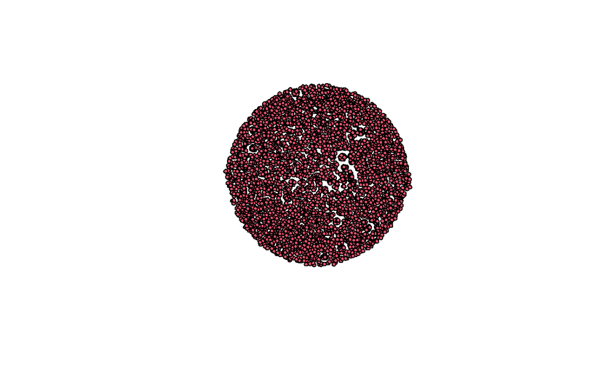

```r
plot(network.stat)
```

```r
options(warn=0)
```

```r
# Calculate the Component Size Distribution of the Graph

n1 = data.frame(Gene = (network.stat%v%'vertex.names'), membership = sna::component.dist(network.stat, connected=c("strong"))$membership, cdist = sna::component.dist(network.stat, connected=c("strong"))$cdist)

n2 = data.frame(csize = sna::component.dist(network.stat,connected=c("strong"))$csize)
# n3 = data.frame(cdist = sna::component.dist(network.stat, connected=c("strong"))$cdist)
```

```r
# getting network density

network.density(network.stat)
```

```
[1] 0.0009092834
```

```r
# network density without loops

gden(network.stat, diag = FALSE)
```

```
[1] 0.0009092834
```

```r
# Average network degree

sort(sna::degree(network.stat), decreasing = T)
```

```
   [1] 82 82 82 70 70 70 60 58 58 58 56 54 48 48 48 46 46 46 46 46 46
  [22] 46 46 46 46 46 46 46 46 46 46 46 44 44 44 44 42 42 42 42 42 40
  [43] 40 40 40 38 38 38 38 38 38 38 38 36 36 36 36 36 36 36 36 36 36
  [64] 36 36 36 36 36 36 36 36 36 36 36 36 36 36 36 36 36 36 36 36 36
  [85] 36 36 36 36 36 34 34 34 34 34 34 34 34 34 34 34 34 34 34 34 34
 [106] 34 34 34 34 34 34 34 34 32 32 32 32 32 32 32 32 32 32 32 32 32
 [127] 32 32 32 32 32 32 32 32 32 32 32 32 32 32 32 30 30 30 30 28 28
 [148] 28 28 28 28 28 28 28 28 28 28 28 28 28 28 28 28 28 28 28 28 28
 [169] 28 28 28 28 28 28 28 28 28 26 26 26 26 26 26 26 26 26 26 26 26
 [190] 26 26 26 26 26 26 26 26 26 26 26 26 26 26 26 24 24 24 24 24 24
 [211] 24 24 24 24 24 24 24 24 24 24 24 24 24 24 24 24 24 24 24 24 24
 [232] 24 24 24 24 24 24 22 22 22 22 22 22 22 22 22 22 22 22 22 22 22
 [253] 22 22 20 20 20 20 20 20 20 20 20 20 20 20 20 20 20 20 20 20 20
 [274] 20 20 20 20 20 20 20 20 20 20 20 20 20 20 20 20 20 20 20 20 20
 [295] 20 20 20 20 20 20 20 20 20 20 20 20 20 18 18 18 18 18 18 18 18
```

[output cut: 168 more lines]

```r
#creating dataframe of vertex names and degree

data.frame(name = network.stat %v% "vertex.names", degree = sort(sna::degree(network.stat), decreasing = T))
```

```
          name degree
1      CYP17A1     82
2        CYP17     82
3      P450C17     82
4        HADH2     70
5         ERAB     70
6       ACADSB     70
7       HSD3B2     60
8       HADHSC     58
9        SCHAD     58
10       MCCC1     58
11        MCCA     56
12       MCCC2     54
13        MCCB     48
14         AUH     48
```

[output cut: 3809 more lines]

```r
# summary statistics for node attributes

summary(data.frame(name = network.stat %v% "vertex.names",
    totdegree = sna::degree(network.stat)))
```

```
     name             totdegree
 Length:3823        Min.   : 0.000
 Class :character   1st Qu.: 2.000
 Mode  :character   Median : 4.000
                    Mean   : 6.951
                    3rd Qu.: 8.000
                    Max.   :82.000
```

```r
## not getting names of nodes?????
```

[figure not shown]

```r
# plotting a histogram

#plot a histogram: ggplot

network.nodes <- data.frame(name = network.stat %v% "vertex.names", degree = sort(sna::degree(network.stat), decreasing = T))

ggplot(network.nodes, aes(name, degree)) +
  geom_col() +
  labs(title = "Gene Distribution", x="Gene Name") + coord_flip()
```

```r
#get network centralization score: statnet

# centralization(network.stat, g = NULL, degree, mode = "graph", diag = FALSE)
```

```r
# summarizing the data after grouping the Gene type

network.nodes%>%
  group_by(name)%>%
  summarise_all(funs(mean, n()))
```

```
# A tibble: 3,823 x 3
   name    mean     n
   <chr>  <dbl> <int>
 1 A15        2     1
 2 A2M       20     1
 3 A4GALT    10     1
 4 AAA       44     1
 5 AAAS      44     1
 6 AAC2       0     1
 7 AACT      24     1
 8 AANAT      6     1
 9 AAS       46     1
10 AASS       4     1
# ... with 3,813 more rows
```